# Between-Trip Variance Evaluation Metric

2023-07-10

In constructing the between-trip variance evaluation metric, we start by generating estimates of variance at the stratum-level for each of the current optimization metrics using the equation $N^2\frac{N - n}{N} \frac{1}{n} \frac{\sum_{i=1}^{n} (x-\bar{x})^2}{n-1}$:

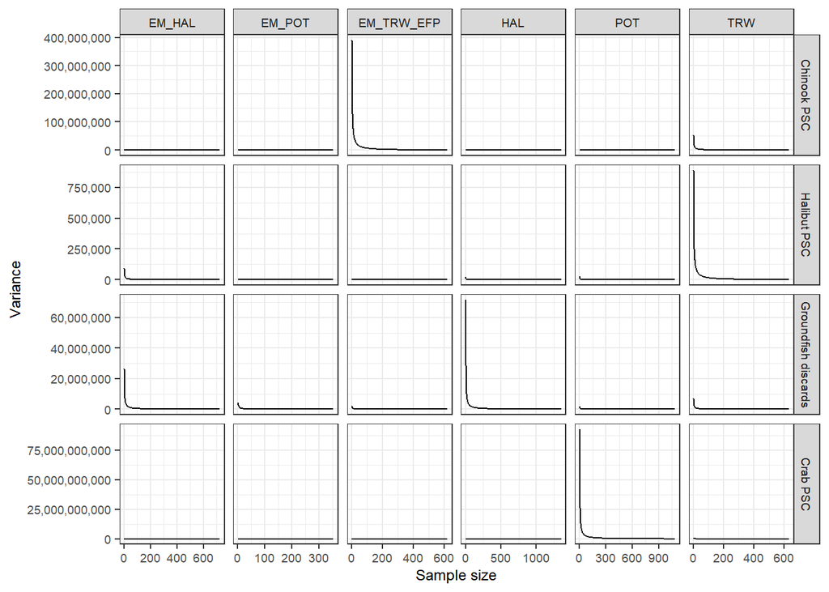

However, it is often easier to speak in terms of standard error, which is the square root of the variance:

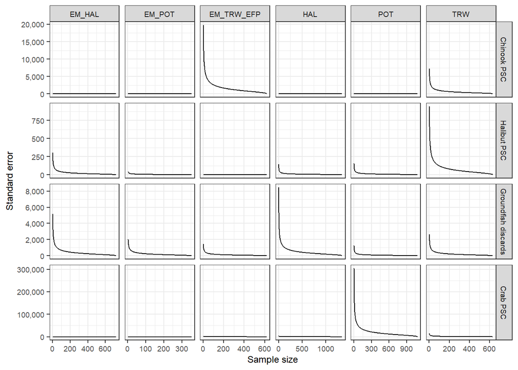

The data used for these estimates excludes zero coverage trips and includes zeros for trips that did not encounter any chinook PSC, halibut PSC, groundfish discards, or crab PSC. An assumption built into this approach is that all four metrics are measured without error at the trip-level, even though that is only true of chinook PSC. If we wanted to see what standard errors would result from two of the allocation schemes proposed in the Draft 2022 ADP (NMFS 2021), we could look at the selection rates that were proposed:

| Allocation scheme | EM_HAL | EM_POT | EM_TRW_EFP | HAL | POT | TRW |
| --- | --- | --- | --- | --- | --- | --- |
| Equal Rates | 30 | 30 | 33.33 | 19.44 | 19.44 | 19.44 |
| 15% + Opt 0.95 | 30 | 30 | 33.33 | 18.21 | 17.48 | 28.10 |

And the standard errors associated with those selection rates:

| Allocation scheme | Metric | Standard error EM_HAL | Standard error EM_POT | Standard error EM_TRW_EFP | Standard error HAL | Standard error POT | Standard error TRW | Standard error Total | Catch Estimate | CV |
| --- | --- | --- | --- | --- | --- | --- | --- | --- | --- | --- |
| Equal Rates | Chinook PSC | 0 | 0 | 1,586 | 0 | 0 | 831 | 1,790 | 13,840 | 0.13 |
| 15% + Opt 0.95 | Chinook PSC | 0 | 0 | 1,586 | 0 | 0 | 655 | 1,716 | 13,840 | 0.12 |
| Equal Rates | Halibut PSC | 24 | 5 | 0 | 11 | 14 | 108 | 112 | 659 | 0.17 |
| 15% + Opt 0.95 | Halibut PSC | 24 | 5 | 0 | 12 | 15 | 85 | 91 | 659 | 0.14 |
| Equal Rates | Groundfish discards | 414 | 231 | 118 | 664 | 111 | 305 | 886 | 16,626 | 0.05 |
| 15% + Opt 0.95 | Groundfish discards | 414 | 231 | 118 | 692 | 118 | 240 | 888 | 16,626 | 0.05 |
| Equal Rates | Crab PSC | 0 | 0 | 156 | 320 | 26,650 | 1,651 | 26,703 | 135,903 | 0.20 |
| 15% + Opt 0.95 | Crab PSC | 0 | 0 | 156 | 333 | 28,419 | 1,301 | 28,451 | 135,903 | 0.21 |

The total standard error for each allocation strategy and metric combination is the square root of the summed stratum-level variances, and is therefore not equal to the sum of the standard errors for each stratum. Although the simplifying assumptions built into this evaluation result in standard errors that are not equal to those we would expect out of the Catch Accounting System, the standard errors produced here do show the relative impact that changes to selection rates have on uncertainty at the trip-level, which is the level at which observer and EM deployment is planned. The analyst team chose CV as the metric:

| Allocation scheme | Metric | CV |
| --- | --- | --- |
| Equal Rates | Chinook PSC | 0.13 |
| 15% + Opt 0.95 | Chinook PSC | 0.12 |
| Equal Rates | Halibut PSC | 0.17 |
| 15% + Opt 0.95 | Halibut PSC | 0.14 |
| Equal Rates | Groundfish discards | 0.05 |
| 15% + Opt 0.95 | Groundfish discards | 0.05 |
| Equal Rates | Crab PSC | 0.20 |
| 15% + Opt 0.95 | Crab PSC | 0.21 |

I wrote a function that estimates the trip-level mean, variance, standard error, and CV when given a data set of effort, a data set containing the original monitoring status of each trip, a data set containing the PSC and discards associated with the effort, the rates at which the effort will be sampled, and the trip column that data sets should be joined on:

```r
effort <- copy(efrt)[ADP == 2022 & POOL != "ZE"][, ':=' (STRATUM_COL = STRATA)]
rates <- adp_rates[, .(ADP = 2022, STRATUM_COL = STRATA, SAMPLE_RATE = `15% + Opt 0.95`/100)]

evaluate_trip_variance(effort, work.data, trips_melt, rates, effort_wd_join = "TRIP_ID")
```

```
##      metric   mean  variance standard_error     cv
## 1: chnk_psc  13840   2943604           1716 0.1240
## 2: hlbt_psc    659      8249             91 0.1379
## 3:  discard  16626    788477            888 0.0534
## 4: crab_psc 135903 809458318          28451 0.2093
```

```r
effort <- copy(pc_effort.current[POOL != "ZE"])
rates <- rates_2022$CURRENT.MPO_SQ

evaluate_trip_variance(effort, work.data, trips_melt, rates, effort_wd_join = "wd_TRIP_ID")
```

```
##      metric   mean   variance standard_error     cv
## 1: chnk_psc  48536  214250691          14637 0.3016
## 2: hlbt_psc   1200     209916            458 0.3817
## 3:  discard  31093    8343277           2888 0.0929
## 4: crab_psc 181059 3095241579          55635 0.3073
```